# Two-Sample Bootstrap Guide

Alex Damisch

August 26, 2015

## Getting Started

We will examine the `Swahili` dataset, found in the `Stat2Data` package. First, install the `Stat2Data` package, then load it into your library, then load the dataset `Swahili`. We will also need to install and load the `mosaic` package, and the `ggplot2` package for some graphs.

If you’ve used any of these packages before, you don’t need to reinstall them, just load them into your library.

```r
install.packages("Stat2Data")
install.packages("mosaic")
install.packages("ggplot2")
```

```r
library(Stat2Data)
library(ggplot2)
library(mosaic)
data(Swahili)
```

You can look at the help file for this data set by typing `?Swahili` into your console.

```r
head(Swahili)
```

```
##   Province  Sex Attitude.Score School
## 1  NAIROBI male            118      A
## 2  NAIROBI male            125      A
## 3  NAIROBI male            120      A
## 4  NAIROBI male            120      A
## 5  NAIROBI male            120      A
## 6  NAIROBI male            121      A
```

```r
summary(Swahili)
```

```
##     Province       Sex      Attitude.Score      School
##  NAIROBI:240   female:240   Min.   :104.0   A      : 40
##  PWANI  :240   male  :240   1st Qu.:141.0   B      : 40
##                             Median :150.0   C      : 40
##                             Mean   :147.1   D      : 40
##                             3rd Qu.:157.0   E      : 40
##                             Max.   :175.0   F      : 40
##                                             (Other):240
```

## Initial Problem

As the summary tells us, there is data from 480 students from 12 different schools (A-L) in this data set, 6 from the Nairobi province and 6 from the Pwani province. All of the 480 students took the same test about their attitudes towards Swahili. A natural question may be whether or not there is a significant difference in the attitude scores of students from the Nairobi province and the Pwani province.

It would seem that the tools that we used for one-sample bootstrapping are inadequate here. The summary does not tell us how the two schools differ from each other. We can plot a histogram, but it does not tell us which province’s students rated which scores.

```
## stat_bin: binwidth defaulted to range/30. Use 'binwidth = x' to adjust this.
```

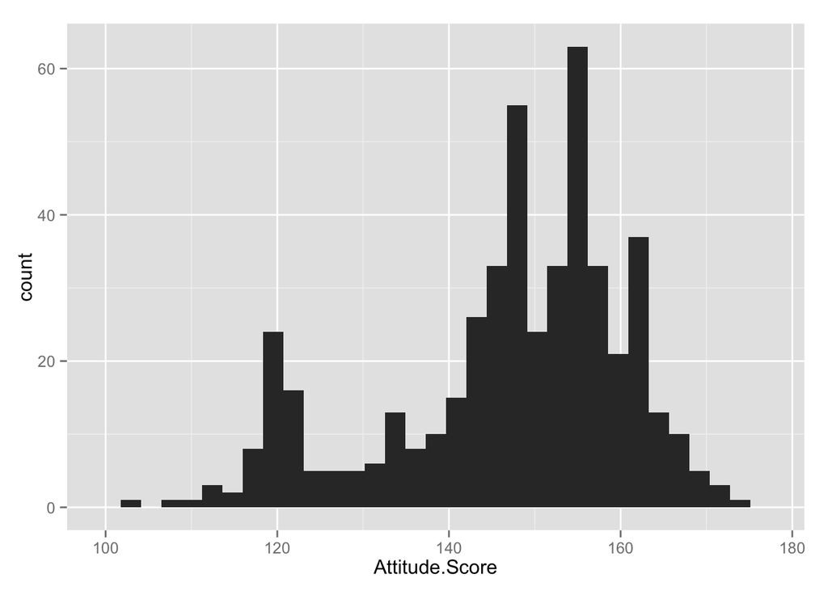

```r
qplot(Attitude.Score, data=Swahili)
```

We need some way to look at the difference between the two provinces. We can make a qplot and add an extra argument to differentiate the colors by province:

```
## stat_bin: binwidth defaulted to range/30. Use 'binwidth = x' to adjust this.
```

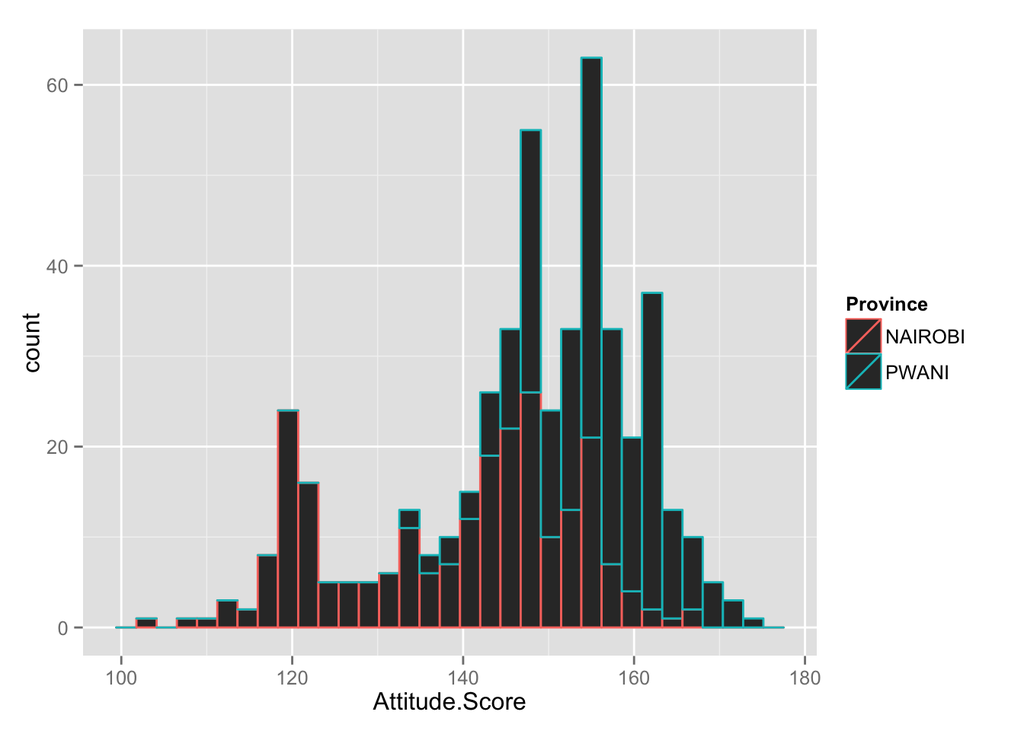

```r
qplot(Attitude.Score, color=Province, data=Swahili)
```

But it is bad practice to have the two stacked on top of each other, as it is more difficult to judge relative frequency.

We will go more in-depth with better graphs in later sections. However, it is first important to cover the summary statistics for the two. We can use `favstats` in the `mosaic` package, and use the `groups` argument to specify which groups we want to examine:

```r
favstats(Attitude.Score, groups=Province, data=Swahili)
```

```
##   Province min     Q1 median     Q3 max     mean        sd   n missing
## 1  NAIROBI 104 125.00    142 149.25 168 138.9042 13.988458 240       0
## 2    PWANI 134 150.75    156 161.00 175 155.3042  7.513112 240       0
```

Another way to phrase this is using the `~` (tilde) to indicate `Attitude.Score` as an explanatory variable variable (for example, when defining linear models in R, response variables are placed to the left of a `~` and explanatory variables are placed to the right). A `|` vertical bar separates the explanatory variable from the variable to group by.

```r
favstats(~Attitude.Score|Province, data=Swahili)
```

```
##   Province min     Q1 median     Q3 max     mean        sd   n missing
## 1  NAIROBI 104 125.00    142 149.25 168 138.9042 13.988458 240       0
## 2    PWANI 134 150.75    156 161.00 175 155.3042  7.513112 240       0
```

## Plots

### Histograms

As pictured above, we can make histograms that differentiate between the two groups with the `qplot` function, but it is a better habit to simply make different graphs for the different groups. It would be tiresome to make two different qplots and look at them siultaneously in R’s viewer window. However, there are built-in functions in the `ggplot2` package that can help us out.

`ggplot` is the name of a function in the `ggplot2` package. All `ggplot` arguments begin like this:

```r
ggplot(dataSet, aes(x=xVariableName, y=yVariableName)) + geom_GeomName()
```

The names of the dataset and the x and y variables (where applicable) are in the `ggplot()` function, with the latter two wrapped in an `aes()` (aesthetics) argument. We then add the geometry for the plot with a separate argument. Most geoms are of the form `geom_` and then the name of the geometry.

For example, we could make a basic histogram like this:

```
## stat_bin: binwidth defaulted to range/30. Use 'binwidth = x' to adjust this.
```

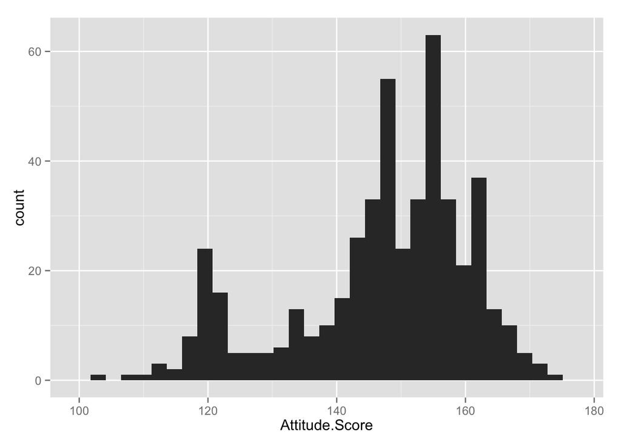

```r
ggplot(Swahili, aes(x=Attitude.Score)) + geom_histogram()
```

It looks like the one we made with the `qplot` function. However, `ggplot` is more flexible–we can keep adding functions like we added `geom_histogram()`. There is a function called `facet_wrap()` grid that allows us to create facetted histograms based on a certain categorical variable. We use the `~` to show which variables we want to facet by–here, they become the explanatory variable to `facet_wrap`. For example, if we wanted, we could make two different histograms, one for male students and one for female students:

```
## stat_bin: binwidth defaulted to range/30. Use 'binwidth = x' to adjust this.
## stat_bin: binwidth defaulted to range/30. Use 'binwidth = x' to adjust this.
```

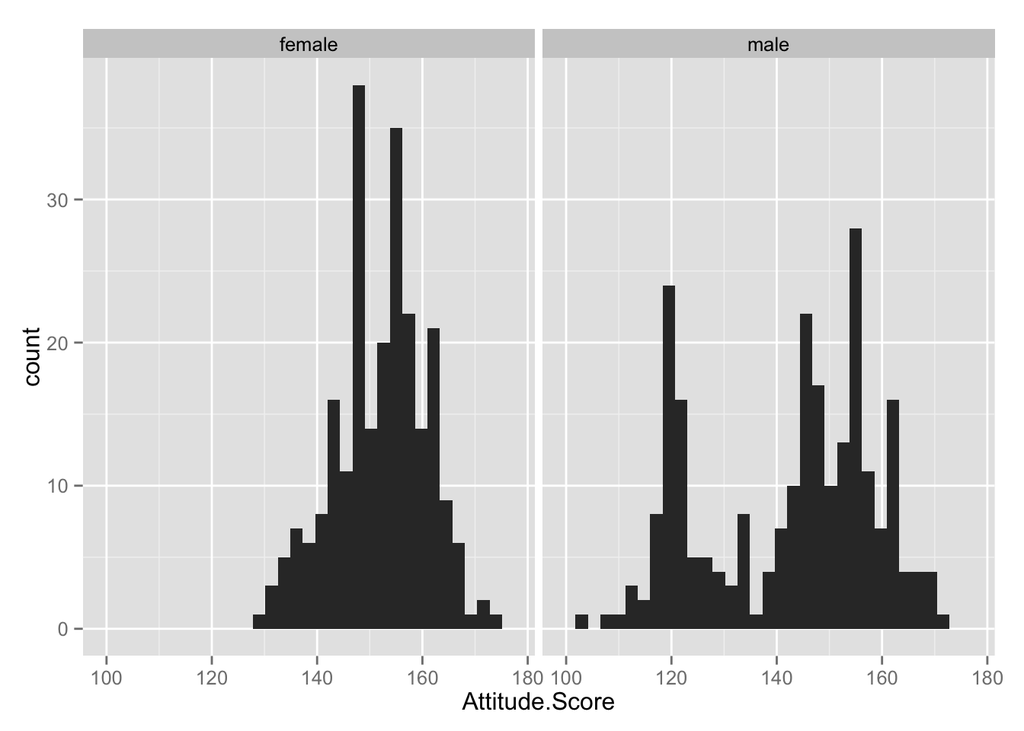

```r
ggplot(Swahili, aes(x=Attitude.Score)) + geom_histogram() + facet_wrap(~Sex)
```

So, for our purposes, we can make two graphs which vary by province, with the same scale:

```
## stat_bin: binwidth defaulted to range/30. Use 'binwidth = x' to adjust this.
## stat_bin: binwidth defaulted to range/30. Use 'binwidth = x' to adjust this.
```

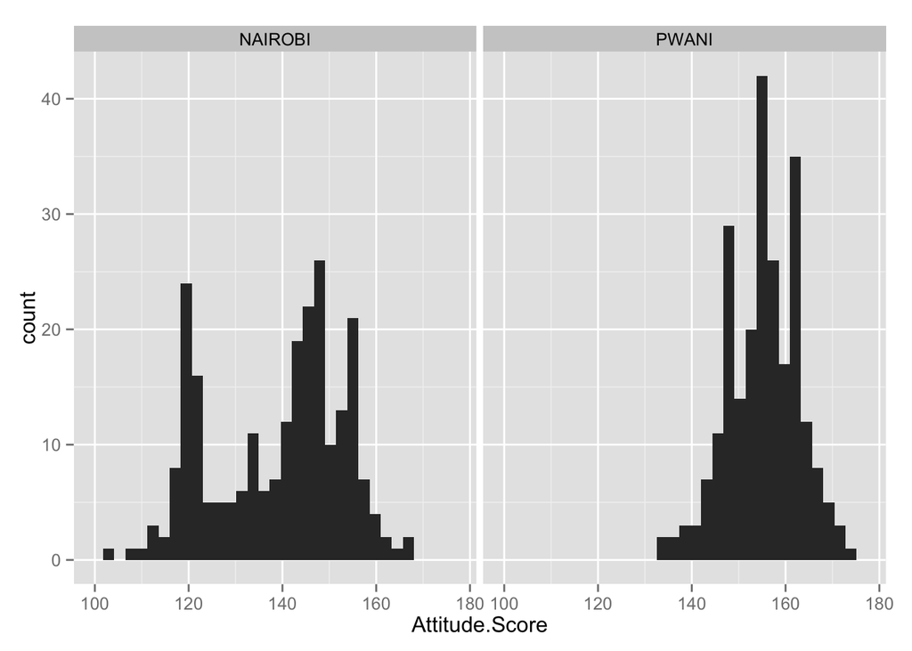

```r
ggplot(Swahili, aes(x=Attitude.Score)) + geom_histogram() + facet_wrap(~Province)
```

If we wanted to, we could change the binwidths of the histograms the same way that we did for one-sample plots; however, one must keep in mind that both graphs will have the same scale. Because the binwidth affects the histogram, the `binwidth` argument goes in the `geom_histogram()` function.

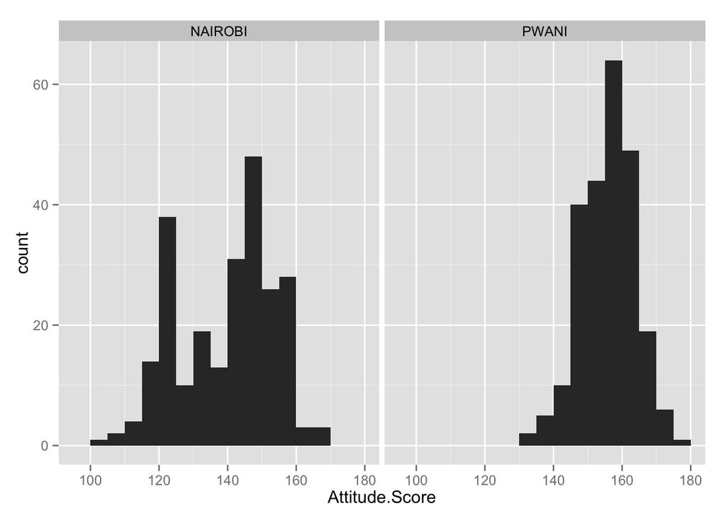

```r
ggplot(Swahili, aes(x=Attitude.Score)) + geom_histogram(binwidth=5) + facet_wrap(~Province)
```

### Density Plots

Once we know how to manipulate `ggplot`, it’s not hard to make other plots of the same type. `ggplot` has a `geom_density()` function, so we can replace `geom_histogram()` with that.

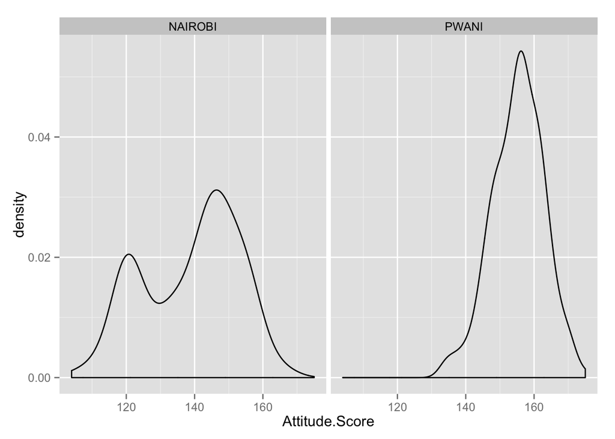

```r
ggplot(Swahili, aes(x=Attitude.Score)) + geom_density() + facet_wrap(~Province)
```

### Q-Q Plots

`ggplot2` has a `stat_qq()` function that makes Q-Q plots about as easy as we’ve had before. However, there is a small change in the `ggplot()` function–instead of using `x=Attitude.Score`, we use `sample=Attitude.Score`, indicating that we’re plotting the sample quantiles against the theoretical quantiles, which are calculated by `stat.qq()`.

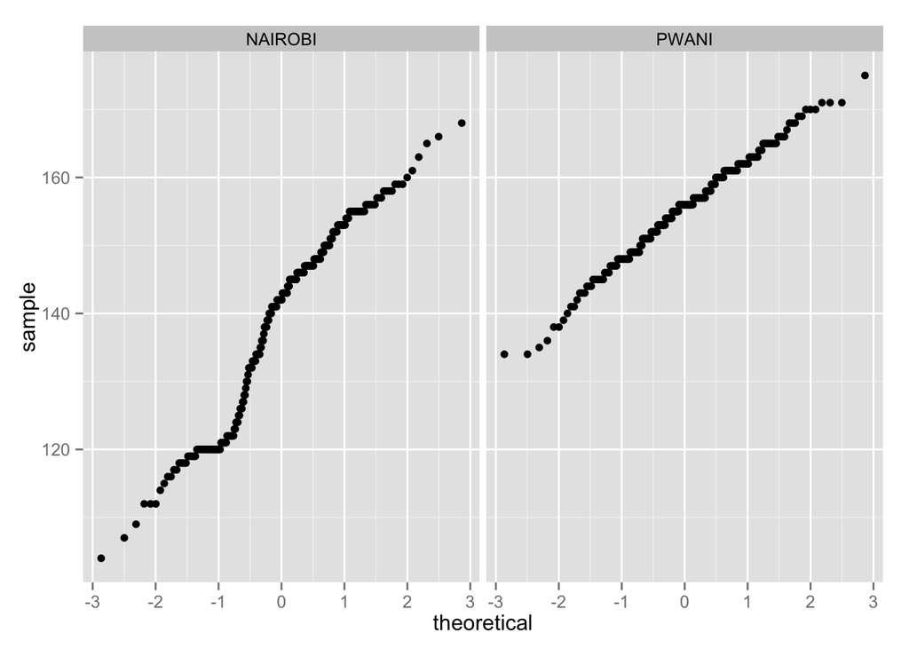

```r
ggplot(Swahili, aes(sample = Attitude.Score)) + stat_qq() + facet_wrap(~Province)
```

These are not necessarily bad charts; however, when looking at Q-Q plots it important to be able to draw a 45˚ line, either mentally or manually, to judge the normality of the points. The `theme()` function in `ggplot2` allows control over almost every imaginable aspect of the plots: the size, font, and color of the axis labels; the color of the grid lines, the position of the legend, etc. (Type `?theme` into the console to see some of the examples.) One way to make judging the normality of these plots easier would be to change their aspect ratio to being square, or a length/width ratio of 1. We can introduce an `aspect.ratio` argument to the `theme`function like so:

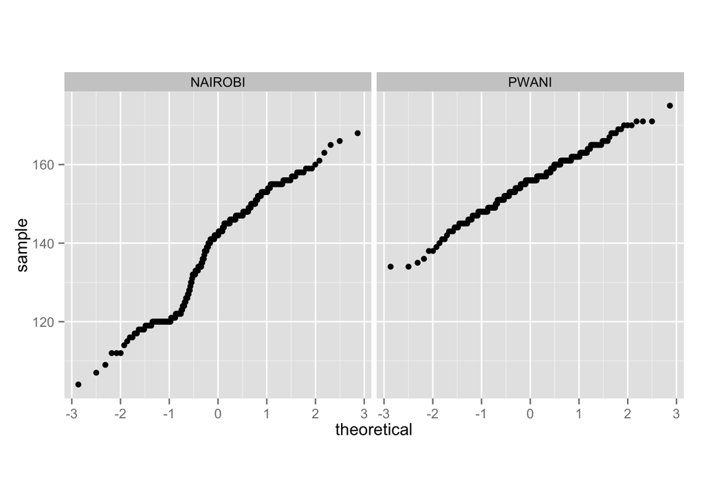

```r
ggplot(Swahili, aes(sample=Attitude.Score)) + stat_qq() + facet_wrap(~Province) + theme(aspect.ratio=1)
```

Try out some other arguments to `theme()`. Then it’s time to resample.

## Resampling

### Grouping

Now that we’ve separately graphed various aspects of the two groups, we have to separately sample them. First, install and load the `dplyr` package (as usual, if you’ve already installed it, just load it).

```r
install.packages("dplyr")
```

```r
library(dplyr)
```

(Note: If you’ve already loaded the `plyr` package into your library, you may have to detach it to get some of these functions to work.)

`dplyr` has two functions that go together very well–`group_by` and `summarise`. `group_by` groups a data frame by a certain variable. We’ll define a new data frame called `grouped` that groups `Swahili` by `Province`. However, before we perform any operations on `grouped`, it won’t look any different than `Swahili`.

```r
grouped <- group_by(Swahili, Province)
head(grouped)
```

```
## Source: local data frame [6 x 4]
## Groups: Province
##
##   Province  Sex Attitude.Score School
## 1  NAIROBI male            118      A
## 2  NAIROBI male            125      A
## 3  NAIROBI male            120      A
## 4  NAIROBI male            120      A
## 5  NAIROBI male            120      A
## 6  NAIROBI male            121      A
```

Indeed, if we try to apply any of the regular functions to `grouped`, they’ll look the same as they do for `Swahili`.

```r
mean(grouped$Attitude.Score)
```

```
## [1] 147.1042
```

```r
mean(Swahili$Attitude.Score)
```

```
## [1] 147.1042
```

#### Two Values

But the `summarise` command allows us to perform operations on `grouped`, and it recognizes the differences in `grouped`. Here we can calculate the minimum and maximum Attitude.Score per group, and define the column names as minScore and maxScore. We name the table minMax.

```r
(minMax <- summarise(grouped, minScore= min(Attitude.Score), maxScore=max(Attitude.Score)))
```

```
## Source: local data frame [2 x 3]
##
##   Province minScore maxScore
## 1  NAIROBI      104      168
## 2    PWANI      134      175
```

We can also use `summarise` multiple times if we need to make a second level of calculations based off of the ones we just did. However, since `minMax` is a table of the two variables, we have to group again. For example,

```r
summarise(group_by(minMax, Province), range=maxScore-minScore)
```

```
## Source: local data frame [2 x 2]
##
##   Province range
## 1  NAIROBI    64
## 2    PWANI    41
```

#### One Value

In the above example, we were trying to get two values–one for each Province. However, if we were condensing down to a single value overall, such as the differences in means between the two provinces, we would only need to group_by once. The `diff` function finds the difference between two values.

```r
(groupedMeans <- summarise(grouped, mean=mean(Attitude.Score)))
```

```
## Source: local data frame [2 x 2]
##
##   Province     mean
## 1  NAIROBI 138.9042
## 2    PWANI 155.3042
```

```r
(groupedMeanDiff <- summarise(groupedMeans, mean.diff=diff(mean)))
```

```
## Source: local data frame [1 x 1]
##
##   mean.diff
## 1      16.4
```

Note that defining the functions separately above will produce the same result as calling them in a nested way, i.e.

```r
summarise(summarise(grouped, mean=mean(Attitude.Score)), mean.diff=diff(mean))
```

```
## Source: local data frame [1 x 1]
##
##   mean.diff
## 1      16.4
```

### One Resample

If you already know `sample` from one-sample bootstrapping and `group_by`, then taking a resample from two different groups is pretty easy. We use the `sample_n` function in the `dplyr` package to give us samples of equal sizes from the two groups. Unlike the `sample` function we used for the one-sample bootstrap, here we have to specify how large we want the sizes to be. If you don’t remember how large the groups are, you can use `summary` or `?Swahili` to check.

```r
one.resample <- sample_n(grouped, 240, replace=TRUE)
head(one.resample)
```

```
## Source: local data frame [6 x 4]
## Groups: Province
##
##   Province    Sex Attitude.Score School
## 1  NAIROBI female            136      D
## 2  NAIROBI   male            120      A
## 3  NAIROBI female            147      B
## 4  NAIROBI   male            145      E
## 5  NAIROBI   male            158      E
## 6  NAIROBI female            147      B
```

```r
tail(one.resample)
```

```
## Source: local data frame [6 x 4]
## Groups: Province
##
##   Province    Sex Attitude.Score School
## 1    PWANI female            148      K
## 2    PWANI   male            157      H
## 3    PWANI   male            146      L
## 4    PWANI female            151      I
## 5    PWANI   male            162      H
## 6    PWANI   male            149      J
```

Again, we can use `summarise` to see the means of the two groups in our resample.

```r
summarise(group_by(one.resample, Province), mean=mean(Attitude.Score))
```

```
## Source: local data frame [2 x 2]
##
##   Province     mean
## 1  NAIROBI 138.7208
## 2    PWANI 155.4750
```

However, we have not specifically indicated what statistic we are even bootstrapping for! Since I’ve already demonstrated above how to do a difference of means, I’ll show an example of a ratio of means, because the syntax is a hair more complicated. Again, we can used nested `summarise` functions to find the ratio of means between the two groups in our `one.resample`.

```r
summarise(summarise(group_by(one.resample, Province), mean=mean(Attitude.Score)), meanRatio = mean[1]/mean[2])
```

```
## Source: local data frame [1 x 1]
##
##   meanRatio
## 1 0.8922388
```

If you remember your subsetting, this shouldn’t faze you too badly–the first mean divided by the second mean.

### Many Resamples

The step to building a `trials` data set is not conceptually difficult, but syntactically it’s a little ugly. First, let’s make a data set called resamples, made of 1000 resamples from `grouped`. (Do not print this data set. You will regret it.)

```r
resamples <- do(1000)*sample_n(grouped, 240, replace=TRUE)
```

If you type `View(resamples)` into your console after running the code, you’ll see the first 1,000 rows. The different resamples are grouped by `.index` (the first resample has a `.index` of all 1s, the second full resample has a `.index` of all 2s, etc.), and then we want to break those down further by `Province`. Luckily, `group_by` can handle multiple groups at once.

```r
resampleGrouped <- group_by(resamples, .index, Province)
head(resampleGrouped)
```

```
## Source: local data frame [6 x 6]
## Groups: .index, Province
##
##   Province    Sex Attitude.Score School .row .index
## 1  NAIROBI   male            146      E    1      1
## 2  NAIROBI female            157      B    2      1
## 3  NAIROBI female            155      B    3      1
## 4  NAIROBI female            158      B    4      1
## 5  NAIROBI   male            121      A    5      1
## 6  NAIROBI female            136      D    6      1
```

We can then find the means for each Province in resampleGrouped.

```r
resampleGroupedMeans <- summarise(resampleGrouped, mean=mean(Attitude.Score))
head(resampleGroupedMeans)
```

```
## Source: local data frame [6 x 3]
## Groups: .index
##
##   .index Province     mean
## 1      1  NAIROBI 138.2625
## 2      1    PWANI 155.0375
## 3      2  NAIROBI 137.6333
## 4      2    PWANI 155.9750
## 5      3  NAIROBI 138.4667
## 6      3    PWANI 155.6417
```

Next come the mean differences (substitute with mean ratio if desired).

```r
resampleMeanDiffs <- summarise(resampleGroupedMeans, diff=diff(mean))
head(resampleMeanDiffs)
```

```
## Source: local data frame [6 x 2]
##
##   .index     diff
## 1      1 16.77500
## 2      2 18.34167
## 3      3 17.17500
## 4      4 17.48333
## 5      5 15.75417
## 6      6 16.73750
```

This is our final data set.

```r
trials<- data.frame(resampleMeanDiffs)
head(trials)
```

```
##   .index     diff
## 1      1 16.77500
## 2      2 18.34167
## 3      3 17.17500
## 4      4 17.48333
## 5      5 15.75417
## 6      6 16.73750
```

This was showed step-by-step by purely pedagogical reasons. It is wise to make `resamples` its own function, in case something goes wrong later on–you don’t want to wait 20 seconds every time. But `trials` can also be formed like this:

```r
trials <- data.frame(summarise(summarise(group_by(resamples, .index, Province), mean=mean(Attitude.Score)), diff=diff(mean)))
```

### Plots

By now, you know the drill.

```r
favstats(diff, data=trials)
```

```
##       min      Q1   median       Q3      max     mean        sd    n
##  12.95833 15.6625 16.31042 16.96771 19.65417 16.31533 0.9967215 1000
##  missing
##        0
```

We’ll use `ggplot2` graphics here. We don’t need to use facetting because the dataset has already been broken down into mean differences.

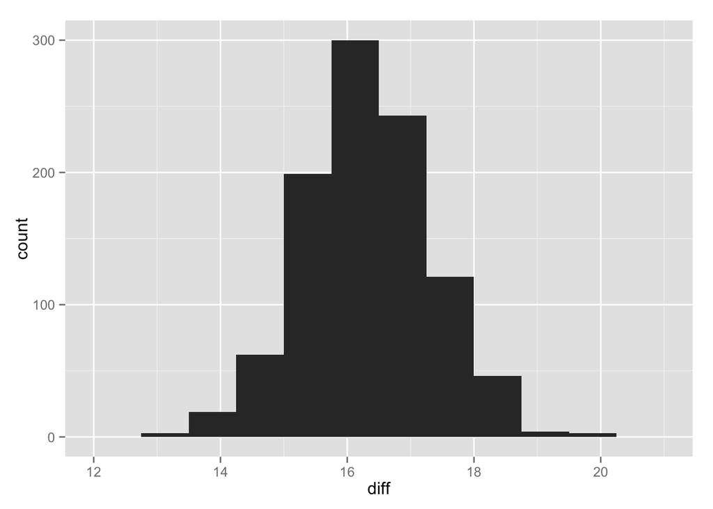

```r
ggplot(trials, aes(x=diff)) + geom_histogram(binwidth=0.75)
```

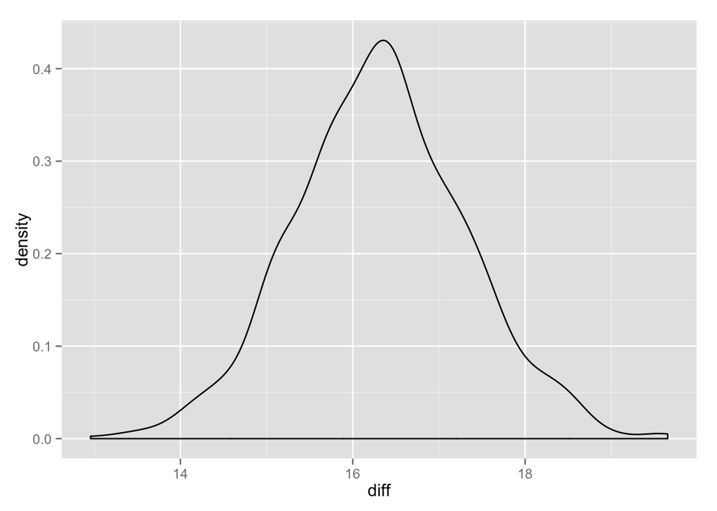

```r
ggplot(trials, aes(x=diff)) + geom_density()
```

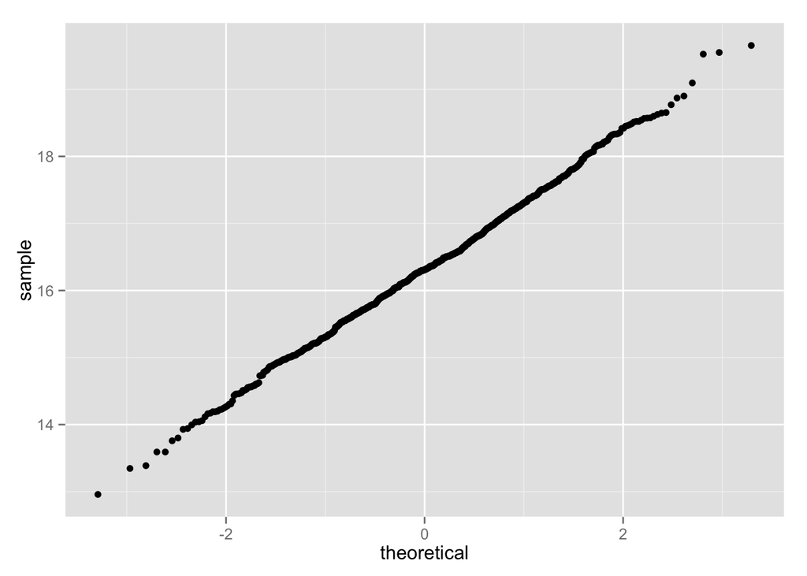

```r
ggplot(trials, aes(sample=diff)) + stat_qq()
```

## Bias and Confidence Intervals

### Bias

Recall that bias is the difference between our original sample statistic and the mean of the bootstrap distribution. We’ve saved the original mean difference as `groupedMeanDiff`.

```r
groupedMeanDiff - mean(trials$diff)
```

```
##   mean.diff
## 1  0.084675
```

### Percentile Confidence Intervals

Confidence intervals for two-sample bootstrapping are very similar to those for one-sample, because we’ve summarized the mean difference (or ratio, etc.) down to a single number.

As always, we need to decide our confidence level. Although 0.95 is standard, we will do 0.9 in this example for demonstration purposes. We’ll define a variable called `level` to represent whatever number you want to put in, and a variable called `alpha` to represent the alpha level.

```r
level <- 0.9
alpha <- 1-level
```

#### Two-Tailed

A two-tailed confidence interval for the `trials` data set requires that we divide `alpha` by 2:

```r
quantile(trials$diff, probs=c(alpha/2, 1-(alpha/2)))
```

```
##       5%      95%
## 14.73313 18.03354
```

#### Lower Bound

For the lower bound, we use `alpha`:

```r
quantile(trials$diff, probs=alpha)
```

```
##      10%
## 15.06167
```

#### Upper Bound

For the upper bound, we use `1-alpha` (equivalent to using `level`):

```r
quantile(trials$diff, probs=1-alpha)
```

```
##      90%
## 17.57542
```

### Normal Confidence Intervals

Normal-based confidence intervals use the mean difference of the original sample, plus or minus the standard error (in this case, the standard deviation of the bootstrap distribution) times quantiles from the normal distribution. `alpha` and `level` are used in the same way.

We saved the mean difference of the original sample as `groupedMeanDiff`.

Here’s the standard error:

```r
SE <- sd(trials$diff)
```

#### Two-Tailed

A two-tailed confidence interval for the `trials` data set requires that we divide `alpha` by 2. We will calculate the lower tail, then the upper tail.

```r
groupedMeanDiff - (qnorm(1-alpha/2) *  SE)
```

```
##   mean.diff
## 1  14.76054
```

```r
groupedMeanDiff + (qnorm(1-alpha/2) * SE)
```

```
##   mean.diff
## 1  18.03946
```

#### Lower Bound

For the lower bound, we use `1-alpha`, but we subtract from the mean difference.

```r
groupedMeanDiff  - (qnorm(1-alpha) * SE)
```

```
##   mean.diff
## 1  15.12265
```

#### Upper Bound

For the upper bound, we also use `1-alpha`, but we add to the mean difference.

```r
groupedMeanDiff  + (qnorm(1-alpha) * SE)
```

```
##   mean.diff
## 1  17.67735
```